# Problem Set 2 Solutions

# Question 1

Suppose $Y_i = {\bf I}_p X_1 + (1-{\bf I}_p) X_2$ for $i=1,\ldots,n$, where the indicator function is defined as
$$\begin{align}
{\bf I}_p & = \begin{cases} 1 & \text{with probability } p \\ 0 & \text{with probability } 1-p\end{cases}
\end{align}$$
and where $p = \frac{1}{3}$, $X_1 \sim N(\mu_1,1)$, and $X_1 \sim N(\mu_2,1)$. That is, the random variables $\{Y_i\}$ are drawn from a discrete mixture of Normals.

### a. (10 points)

Write the join density function for $\{Y_i\}$.

#### Solution:

The univariate density for $Y_i$ is
$$\begin{align}
f_{Y_i}(y_i|\mu_1,\mu_2) & = p \frac{1}{\sqrt{2\pi}} \exp\left\{-\frac{1}{2} (y_i-\mu_1)^2\right\} + (1-p) \frac{1}{\sqrt{2\pi}} \exp\left\{-\frac{1}{2} (y_i-\mu_2)^2\right\}, \,\, \text{for} \,\, i = 1,\ldots,n.
\end{align}$$
Thus, the joint density is
$$\begin{align}
f_{{\bf Y}}({\bf y}|\mu_1,\mu_2) & = \prod_{i=1}^n f_{Y_i}(y_i|p,\mu_1,\mu_2) \\
& = \frac{1}{(2\pi)^{n/2}} \prod_{i=1}^n \left(p \exp\left\{-\frac{1}{2} (y_i-\mu_1)^2\right\} + (1-p) \exp\left\{-\frac{1}{2} (y_i-\mu_2)^2\right\}\right).
\end{align}$$

### b. (10 points)

What is the log likelihood?

#### Solution:

$$\begin{align}
\ell(\mu_1,\mu_2|{\bf y}) & = \log(f_{{\bf Y}}({\bf y}|\mu_1,\mu_2)) \\
& = -\frac{n}{2} \log(2\pi) + \sum_{i=1}^n \log\left(p \exp\left\{-\frac{1}{2} (y_i-\mu_1)^2\right\} + (1-p) \exp\left\{-\frac{1}{2} (y_i-\mu_2)^2\right\}\right).
\end{align}$$

### c. (15 points)

What are the gradient and hessian of the log likelihood?

#### Solution:

$$\begin{align}
{\bf g}(\mu_1,\mu_2|{\bf y}) & = \left[\begin{array}{c} \frac{\partial \ell}{\partial \mu_1} \\ \frac{\partial \ell}{\partial \mu_2}\end{array}\right] \\
& = \sum_{i=1}^n \left[\begin{array}{c} \frac{(y_i-\mu_1) p \exp\left\{-\frac{1}{2} (y_i-\mu_1)^2\right\}}{p \exp\left\{-\frac{1}{2} (y_i-\mu_1)^2\right\} + (1-p) \exp\left\{-\frac{1}{2} (y_i-\mu_2)^2\right\}} \\ \frac{(y_i-\mu_2) (1-p) \exp\left\{-\frac{1}{2} (y_i-\mu_2)^2\right\}}{p \exp\left\{-\frac{1}{2} (y_i-\mu_1)^2\right\} + (1-p) \exp\left\{-\frac{1}{2} (y_i-\mu_2)^2\right\}}\end{array} \right].
\end{align}$$

$$\begin{align}
{\bf H}(\mu_1,\mu_2|{\bf y}) & = \left[\begin{array}{cc} \frac{\partial^2 \ell}{\partial \mu_1^2} & \frac{\partial^2 \ell}{\partial \mu_1 \partial \mu_2} \\ \frac{\partial^2 \ell}{\partial \mu_1 \partial \mu_2} & \frac{\partial^2 \ell}{\partial \mu_2^2}\end{array}\right] \\
& = \sum_{i=1}^n \frac{\mathcal{V}_1 \mathcal{V}_2}{\mathcal{V}_1 + \mathcal{V}_2}\left[\begin{array}{cc} (y_i-\mu_1)^2-1 - \frac{\mathcal{V}_1}{\mathcal{V}_2} & -(y_i-\mu_1)(y_i-\mu_2) \\ -(y_i-\mu_1)(y_i-\mu_2) & (y_i-\mu_2)^2-1 - \frac{\mathcal{V}_2}{\mathcal{V}_1} \end{array} \right],
\end{align}$$
where $\mathcal{V}_1 = p \exp\left\{-\frac{1}{2} (y_i-\mu_1)^2\right\}$ and $\mathcal{V}_2 = (1-p) \exp\left\{-\frac{1}{2} (y_i-\mu_2)^2\right\}$.

### d. (15 points)

Using the simulated data on the course website, compute maximum likelihood estimates of $\mu_1$ ane $\mu_2$ using the Newton-Raphson method.

#### Solution:

Using the code below, it is possible to show that Newton-Raphson is sensitive to the starting values for $\mu_1$ and $\mu_2$. To get reasonable guesses for the starting values, we can plot a histogram or kernel density estimate (essentially smoothed histogram) of the data:

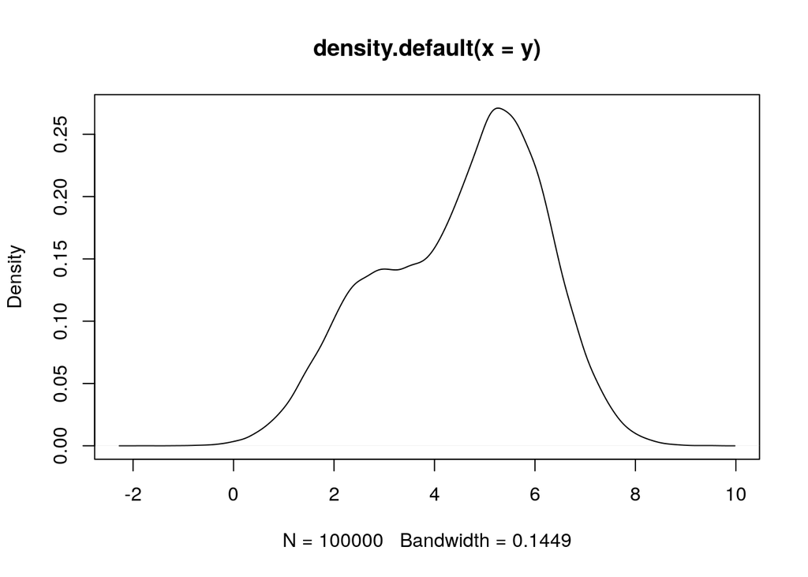

```r
y = read.csv('ps2Data.csv')$x
plot(density(y))
```

```r
tol = 1e-2
tau = 2*tol
p = 1/3
mu0 = c(1,7)
while(tau > tol){
  V1 = p*exp(-0.5*(y-mu0[1])^2)
  V2 = (1-p)*exp(-0.5*(y-mu0[2])^2)
  gradient = c(sum((y-mu0[1])*V1/(V1+V2)),sum((y-mu0[2])*V2/(V1+V2)))
  H11 = sum((((y-mu0[1])^2-1)*V1*V2-V1^2)/(V1+V2))
  H12 = sum(-(y-mu0[1])*(y-mu0[2])*V1*V2/(V1+V2))
  H22 = sum((((y-mu0[2])^2-1)*V1*V2-V2^2)/(V1+V2))
  hessian = matrix(c(H11,H12,H12,H22),ncol=2)
  mu1 = mu0 - 0.2*solve(hessian)%*%gradient
  tau = max(abs(mu1-mu0))
  mu0 = mu1
}
print(mu0)
```

```
##          [,1]
## [1,] 2.730306
## [2,] 5.422600
```

# Question 2 (15 points)

Assume the following linear model:
$$\begin{align}
Y & = \beta_1 X_1 + \beta_2 X_2 + \varepsilon, \,\,\, \varepsilon \sim N(0,\sigma^2).
\end{align}$$

### a. (10 points)

Write the expression for the best linear predictor, $\boldsymbol{\beta}^* = (\beta_1,\beta_2)$, with each element of the associated matrices and vectors individually specified.

#### Solution:

From the lecture notes, we know that
$$\begin{align}
\boldsymbol{\beta}^* & = \text{E}\left[\bf{X}\bf{X}'\right]^{-1} \text{E}\left[{\bf X} Y\right] \\
& = \text{E}\left[\begin{array}{cc} X_1 X_1 & X_1 X_2 \\ X_2 X_1 & X_2 X_2 \end{array}\right]^{-1} \text{E}\left[\begin{array}{c} X_1 Y \\ X_2 Y \end{array}\right] \\
& = \left[\begin{array}{cc} \text{E}[X_1^2] & \text{E}[X_1 X_2] \\ \text{E}[X_2 X_1] & \text{E}[X_2^2] \end{array}\right]^{-1} \left[\begin{array}{c} \text{E}[X_1 Y] \\ \text{E}[X_2 Y] \end{array}\right] \\
& = \frac{1}{\text{E}[X_1^2] \text{E}[X_2^2] - 2 \text{E}[X_1 X_2]} \left[\begin{array}{cc} \text{E}[X_2^2] & -\text{E}[X_1 X_2] \\ -\text{E}[X_2 X_1] & \text{E}[X_1^2] \end{array}\right] \left[\begin{array}{c} \text{E}[X_1 Y] \\ \text{E}[X_2 Y] \end{array}\right] \\
& = \left[\begin{array}{c} \frac{\text{E}[X_2^2] \text{E}[X_1 Y] - \text{E}[X_1 X_2] \text{E}[X_2 Y]}{\text{E}[X_1^2] \text{E}[X_2^22] - 2 \text{E}[X_1 X_2]} \\ \frac{\text{E}[X_1^2] \text{E}[X_2 Y] - \text{E}[X_1 X_2] \text{E}[X_1 Y]}{\text{E}[X_1^2] \text{E}[X_2^2] - 2 \text{E}[X_1 X_2]} \end{array}\right].
\end{align}$$

### b. (10 points)

Suppose you have $n$ obersvations of $(Y,X_1,X_2)$, collected in vectors ${\bf y}' = (y_1,\ldots,y_n)$, ${\bf x}_1' = (x_{11},\ldots,x_{1n})$, and${\bf x}_2' = (x_{21},\ldots,x_{2n})$. Write the expression for the least-squares estimator $\hat{\boldsymbol{\beta}}$, with each element of the associated matrices and vectors individually specified.

#### Solution:

Setting ${\bf X} = [{\bf x}_1 \,\, {\bf x}_2]$, the formula for the least-squares estimator is
$$\begin{align}
\hat{\boldsymbol{\beta}} & = \left[{\bf X}' {\bf X}\right]^{-1} {\bf X}' {\bf y} \\
& = \left[\begin{array}{cc} \sum_{i=1}^n x_{1i}^2 & \sum_{i=1}^n x_{1i} x_{2i} \\ \sum_{i=1}^n x_{2i} x_{1i} & \sum_{i=1}^n x_{2i}^2 \end{array}\right]^{-1} \left[\begin{array}{c} \sum_{i=1}^n x_{1i} y_i \\ \sum_{i=1}^n x_{2i} y_i\end{array}\right] \\
& = \frac{1}{\sum_{i=1}^n x_{1i}^2 \sum_{i=1}^n x_{2i}^2 - 2 \sum_{i=1}^n x_{1i}x_{2i}} \left[\begin{array}{cc} \sum_{i=1}^n x_{2i}^2 & -\sum_{i=1}^n x_{1i} x_{2i} \\ -\sum_{i=1}^n x_{2i} x_{1i} & \sum_{i=1}^n x_{1i}^2 \end{array}\right] \left[\begin{array}{c} \sum_{i=1}^n x_{1i} y_i \\ \sum_{i=1}^n x_{2i} y_i\end{array}\right] \\
& = \left[\begin{array}{c} \frac{\sum_{i=1}^n x_{2i}^2 \sum_{i=1}^n x_{1i} y_i -\sum_{i=1}^n x_{1i} x_{2i} \sum_{i=1}^n x_{2i} y_i}{\sum_{i=1}^n x_{1i}^2 \sum_{i=1}^n x_{2i}^2 - 2 \sum_{i=1}^n x_{1i}x_{2i}} \\ \frac{\sum_{i=1}^n x_{1i}^2 \sum_{i=1}^n x_{2i} y_i -\sum_{i=1}^n x_{1i} x_{2i} \sum_{i=1}^n x_{1i} y_i}{\sum_{i=1}^n x_{1i}^2 \sum_{i=1}^n x_{2i}^2 - 2 \sum_{i=1}^n x_{1i}x_{2i}}\end{array}\right].
\end{align}$$

### c. (10 points)

How are the solutions to (a) and (b) related?

#### Solution:

Under fairly week conditions, the weak law of large numbers will apply to each of the sums in the solution to (b), resulting in $\sum_{i=1}^n x_{1i}^2 \stackrel{p}{\to} E[X_1^2]$, $\sum_{i=1}^n x_{2i}^2 \stackrel{p}{\to} E[X_2^2]$, $\sum_{i=1}^n x_{1i} x_{2i} \stackrel{p}{\to} E[X_1 X_2]$, $\sum_{i=1}^n x_{1i} y_i \stackrel{p}{\to} E[X_1 Y]$, and $\sum_{i=1}^n x_{2i} y_i \stackrel{p}{\to} E[X_2 Y]$, as $n \to \infty$. As a consequence, $\hat{\boldsymbol{\beta}} \stackrel{p}{\to} \boldsymbol{\beta}^*$.

# Question 3

### a. (10 points)

Using daily returns, compute monthly realized variance by summing the squared returns within each month: $RV_t = \sum_{i=1}^n r_{t+i}^2$, where $t$ denotes the month, $i$ indexes the days within the month, and $n$ represents the number of trading days in the month (typically around 22). Plot the time series of realized variance.

#### Solution:

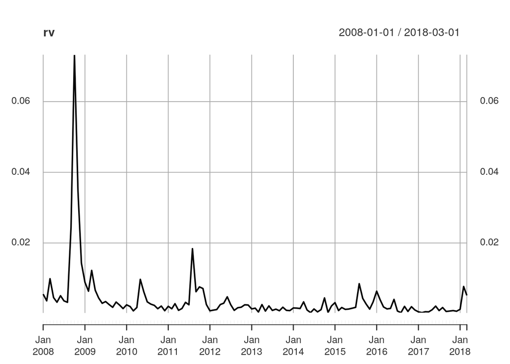

```r
library(Quandl)
library(quantmod)
library(data.table)
NQ1 = Quandl("CHRIS/CME_NQ1",start_date="2008-01-04",end_date="2018-03-31",type="xts")
nqRets = dailyReturn(NQ1$Settle)
nqRetsTable = data.table(index(nqRets),nqRets,year(index(nqRets)),month(index(nqRets)))
colnames(nqRetsTable) = c("date","returns","year","month")
rvTable = nqRetsTable[,.(sum(returns^2)),by=.(year,month)]
rv = as.xts(rvTable$V1,order.by=as.Date(paste0(as.character(rvTable$year),"/",as.character(rvTable$month),"/01")))
colnames(rv) = "RV"
plot(rv,type='l')
```

### b. (10 points)

Find the best fitting ARMA model for the log of realized variance. Report the parameter estimates and standard errors and provide some interpretation.

#### Solution:

A sample ACF plot of the realized variance suggests that an appropriate model might be an $MA(2)$, since the estimated autocorrelations are no longer significant after lag 2:

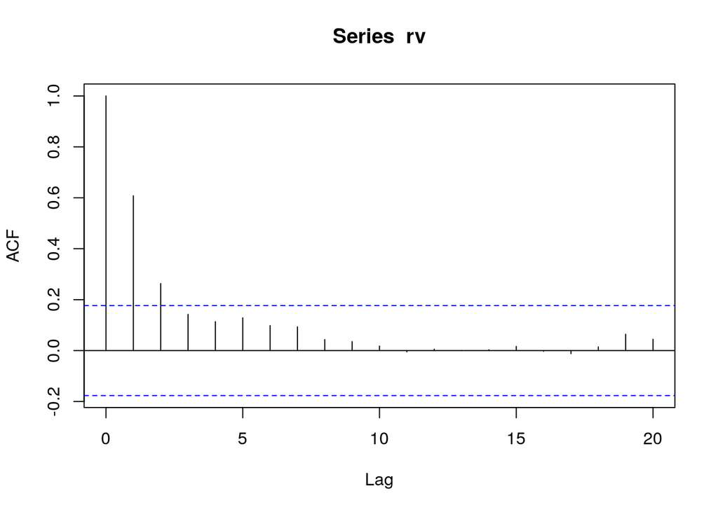

```r
acf(rv)
```

The estimated $MA(2)$ results in the following coefficients and standard errors:

```r
estOut = arima(rv,order=c(0,0,2))
#summary(estOut)
estOut$coef
```

```
##         ma1         ma2   intercept
## 0.700041242 0.211905374 0.003871607
```

```r
sqrt(diag(estOut$var.coef))
```

```
##         ma1         ma2   intercept
## 0.083445936 0.092830651 0.001041362
```

which are significant at the 5% level. A residual plot suggests that the model is somewhat lacking:

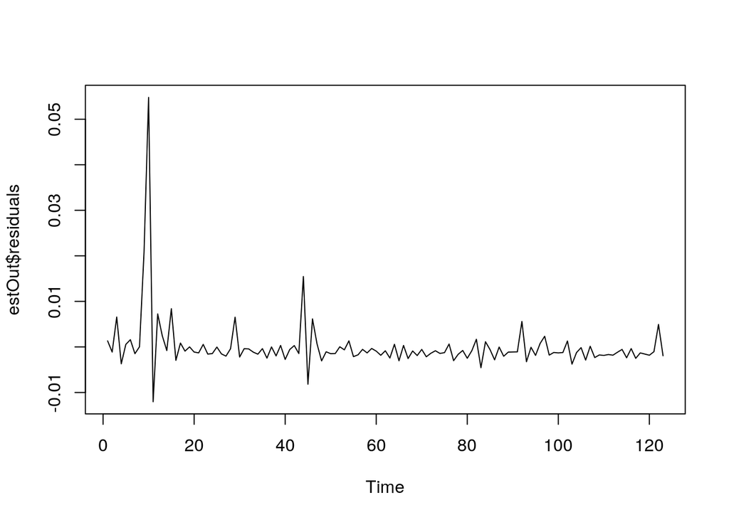

```r
plot(estOut$residuals)
```

Clearly, the residuals suggest a poor fit. In fact, the original plot of the data suggests that they are not stationary – the variance of RV is clearly not constant throught time. Further, RV is a strictly positive variable, which is not appropriate for an $ARMA$ model (where the shocks, and hence the response variable, are allowed to be negative). One possibility is to consider a model for the log of RV:

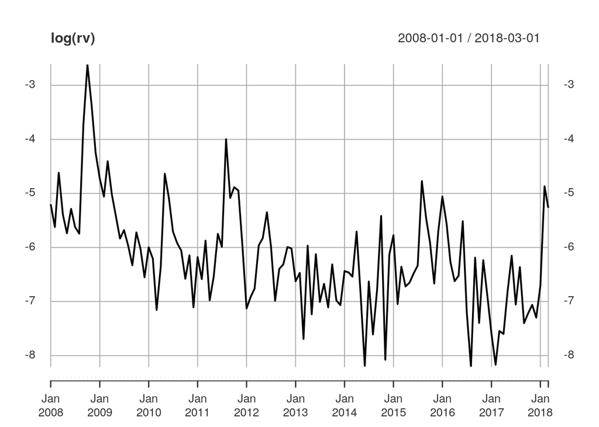

```r
plot(log(rv))
```

$\log(RV)$ looks like a more appropriate input for an $ARMA$ model. Recomputing the sample ACF:

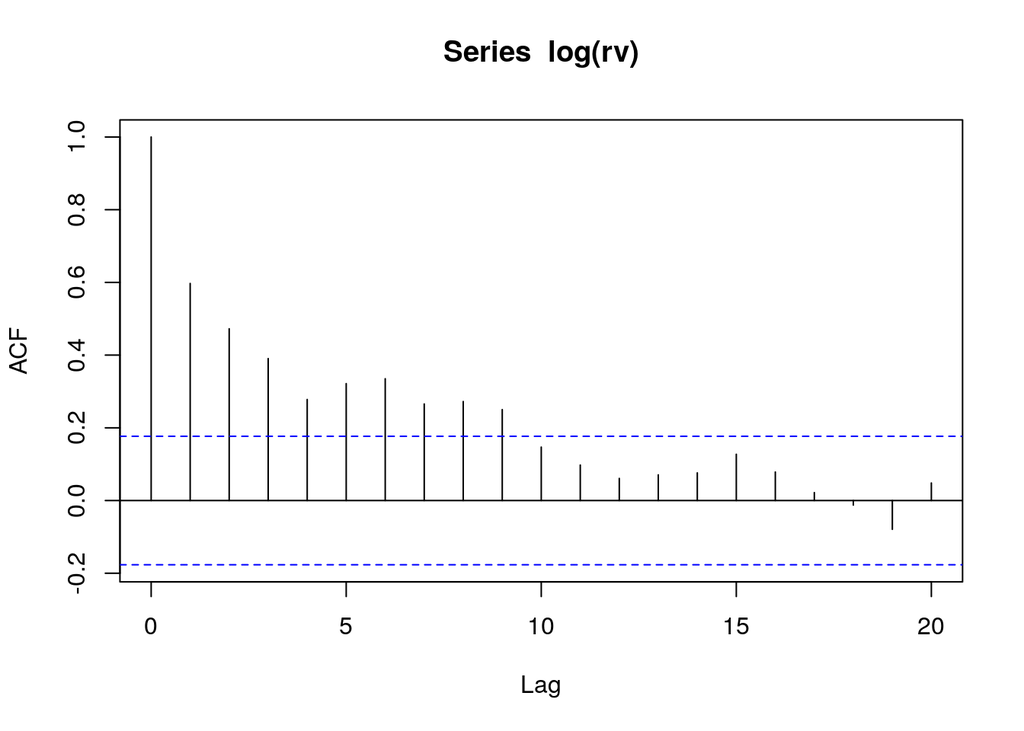

```r
acf(log(rv))
```

Which suggests that the data have at least one $AR$ component. In fact the function `auto.arima` selects an $ARMA(1,1)$ model for the first differences of $\log(RV)$, but since I have no theoretical reason to believe we should take first differences, I constrain the $d$ parameter in the $ARIMA$ model to be zero:

```r
library(forecast)
logEstOut = auto.arima(log(rv),max.d=0)
logEstOut
```

```
## Series: log(rv)
## ARIMA(1,0,1) with non-zero mean
##
## Coefficients:
##          ar1      ma1     mean
##       0.8183  -0.3591  -6.1118
## s.e.  0.0864   0.1489   0.2360
##
## sigma^2 estimated as 0.5943:  log likelihood=-141.28
## AIC=290.56   AICc=290.9   BIC=301.81
```

The resulting residuals look much better:

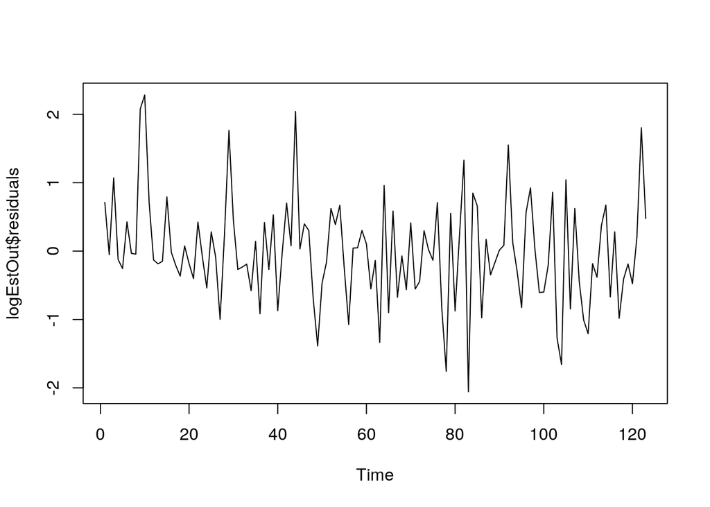

```r
plot(logEstOut$residuals)
```

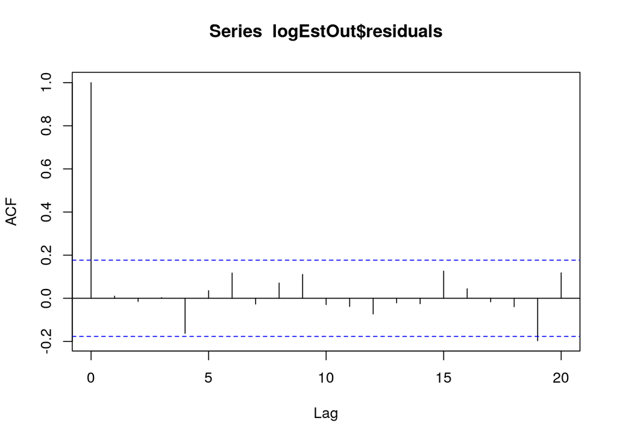

```r
acf(logEstOut$residuals)
```